# Prosper Loan Data Exploration

## Preliminary Wrangling

This data set contains 113,937 loans with 81 variables on each loan, including loan amount, borrower rate (or interest rate), current loan status, borrower income, and many others.

```python
import pandas as pd
import numpy as np
import matplotlib.pyplot as plt
import seaborn as sb
%matplotlib inline
```

## Data Wrangling

```python
loan = pd.read_csv("prosperLoanData.csv")
loan.head()
```

|  | ListingKey | ListingNumber | ListingCreationDate | CreditGrade | Term | LoanStatus | ClosedDate | BorrowerAPR | BorrowerRate | LenderYield | ... | LP_ServiceFees | LP_CollectionFees | LP_GrossPrincipalLoss | LP_NetPrincipalLoss | LP_NonPrincipalRecoverypayments | PercentFunded | Recommendations | InvestmentFromFriendsCount | InvestmentFromFriendsAmount | Investors |
| --- | --- | --- | --- | --- | --- | --- | --- | --- | --- | --- | --- | --- | --- | --- | --- | --- | --- | --- | --- | --- | --- |
| 0 | 1021339766868145413AB3B | 193129 | 2007-08-26 19:09:29.263000000 | C | 36 | Completed | 2009-08-14 00:00:00 | 0.16516 | 0.1580 | 0.1380 | ... | -133.18 | 0.0 | 0.0 | 0.0 | 0.0 | 1.0 | 0 | 0 | 0.0 | 258 |
| 1 | 10273602499503308B223C1 | 1209647 | 2014-02-27 08:28:07.900000000 | NaN | 36 | Current | NaN | 0.12016 | 0.0920 | 0.0820 | ... | 0.00 | 0.0 | 0.0 | 0.0 | 0.0 | 1.0 | 0 | 0 | 0.0 | 1 |
| 2 | 0EE9337825851032864889A | 81716 | 2007-01-05 15:00:47.090000000 | HR | 36 | Completed | 2009-12-17 00:00:00 | 0.28269 | 0.2750 | 0.2400 | ... | -24.20 | 0.0 | 0.0 | 0.0 | 0.0 | 1.0 | 0 | 0 | 0.0 | 41 |
| 3 | 0EF5356002482715299901A | 658116 | 2012-10-22 11:02:35.010000000 | NaN | 36 | Current | NaN | 0.12528 | 0.0974 | 0.0874 | ... | -108.01 | 0.0 | 0.0 | 0.0 | 0.0 | 1.0 | 0 | 0 | 0.0 | 158 |
| 4 | 0F023589499656230C5E3E2 | 909464 | 2013-09-14 18:38:39.097000000 | NaN | 36 | Current | NaN | 0.24614 | 0.2085 | 0.1985 | ... | -60.27 | 0.0 | 0.0 | 0.0 | 0.0 | 1.0 | 0 | 0 | 0.0 | 20 |

5 rows × 81 columns

### Assessing

```python
loan.shape
```

```
(113937, 81)
```

```python
loan.info()
```

```
<class 'pandas.core.frame.DataFrame'>
RangeIndex: 113937 entries, 0 to 113936
Data columns (total 81 columns):
ListingKey                             113937 non-null object
ListingNumber                          113937 non-null int64
ListingCreationDate                    113937 non-null object
CreditGrade                            28953 non-null object
Term                                   113937 non-null int64
LoanStatus                             113937 non-null object
ClosedDate                             55089 non-null object
BorrowerAPR                            113912 non-null float64
BorrowerRate                           113937 non-null float64
LenderYield                            113937 non-null float64
EstimatedEffectiveYield                84853 non-null float64
EstimatedLoss                          84853 non-null float64
EstimatedReturn                        84853 non-null float64
ProsperRating (numeric)                84853 non-null float64
ProsperRating (Alpha)                  84853 non-null object
ProsperScore                           84853 non-null float64
ListingCategory (numeric)              113937 non-null int64
BorrowerState                          108422 non-null object
Occupation                             110349 non-null object
EmploymentStatus                       111682 non-null object
EmploymentStatusDuration               106312 non-null float64
IsBorrowerHomeowner                    113937 non-null bool
CurrentlyInGroup                       113937 non-null bool
GroupKey                               13341 non-null object
DateCreditPulled                       113937 non-null object
CreditScoreRangeLower                  113346 non-null float64
CreditScoreRangeUpper                  113346 non-null float64
FirstRecordedCreditLine                113240 non-null object
CurrentCreditLines                     106333 non-null float64
OpenCreditLines                        106333 non-null float64
TotalCreditLinespast7years             113240 non-null float64
OpenRevolvingAccounts                  113937 non-null int64
OpenRevolvingMonthlyPayment            113937 non-null float64
InquiriesLast6Months                   113240 non-null float64
TotalInquiries                         112778 non-null float64
CurrentDelinquencies                   113240 non-null float64
AmountDelinquent                       106315 non-null float64
```

[output cut: 31 more lines]

```
LP_CustomerPayments                    113937 non-null float64
LP_CustomerPrincipalPayments           113937 non-null float64
LP_InterestandFees                     113937 non-null float64
LP_ServiceFees                         113937 non-null float64
LP_CollectionFees                      113937 non-null float64
LP_GrossPrincipalLoss                  113937 non-null float64
LP_NetPrincipalLoss                    113937 non-null float64
LP_NonPrincipalRecoverypayments        113937 non-null float64
PercentFunded                          113937 non-null float64
Recommendations                        113937 non-null int64
InvestmentFromFriendsCount             113937 non-null int64
InvestmentFromFriendsAmount            113937 non-null float64
Investors                              113937 non-null int64
dtypes: bool(3), float64(50), int64(11), object(17)
memory usage: 68.1+ MB
```

```python
loan.describe()
```

|  | ListingNumber | Term | BorrowerAPR | BorrowerRate | LenderYield | EstimatedEffectiveYield | EstimatedLoss | EstimatedReturn | ProsperRating (numeric) | ProsperScore | ... | LP_ServiceFees | LP_CollectionFees | LP_GrossPrincipalLoss | LP_NetPrincipalLoss | LP_NonPrincipalRecoverypayments | PercentFunded | Recommendations | InvestmentFromFriendsCount | InvestmentFromFriendsAmount | Investors |
| --- | --- | --- | --- | --- | --- | --- | --- | --- | --- | --- | --- | --- | --- | --- | --- | --- | --- | --- | --- | --- | --- |
| count | 1.139370e+05 | 113937.000000 | 113912.000000 | 113937.000000 | 113937.000000 | 84853.000000 | 84853.000000 | 84853.000000 | 84853.000000 | 84853.000000 | ... | 113937.000000 | 113937.000000 | 113937.000000 | 113937.000000 | 113937.000000 | 113937.000000 | 113937.000000 | 113937.000000 | 113937.000000 | 113937.000000 |
| mean | 6.278857e+05 | 40.830248 | 0.218828 | 0.192764 | 0.182701 | 0.168661 | 0.080306 | 0.096068 | 4.072243 | 5.950067 | ... | -54.725641 | -14.242698 | 700.446342 | 681.420499 | 25.142686 | 0.998584 | 0.048027 | 0.023460 | 16.550751 | 80.475228 |
| std | 3.280762e+05 | 10.436212 | 0.080364 | 0.074818 | 0.074516 | 0.068467 | 0.046764 | 0.030403 | 1.673227 | 2.376501 | ... | 60.675425 | 109.232758 | 2388.513831 | 2357.167068 | 275.657937 | 0.017919 | 0.332353 | 0.232412 | 294.545422 | 103.239020 |
| min | 4.000000e+00 | 12.000000 | 0.006530 | 0.000000 | -0.010000 | -0.182700 | 0.004900 | -0.182700 | 1.000000 | 1.000000 | ... | -664.870000 | -9274.750000 | -94.200000 | -954.550000 | 0.000000 | 0.700000 | 0.000000 | 0.000000 | 0.000000 | 1.000000 |
| 25% | 4.009190e+05 | 36.000000 | 0.156290 | 0.134000 | 0.124200 | 0.115670 | 0.042400 | 0.074080 | 3.000000 | 4.000000 | ... | -73.180000 | 0.000000 | 0.000000 | 0.000000 | 0.000000 | 1.000000 | 0.000000 | 0.000000 | 0.000000 | 2.000000 |
| 50% | 6.005540e+05 | 36.000000 | 0.209760 | 0.184000 | 0.173000 | 0.161500 | 0.072400 | 0.091700 | 4.000000 | 6.000000 | ... | -34.440000 | 0.000000 | 0.000000 | 0.000000 | 0.000000 | 1.000000 | 0.000000 | 0.000000 | 0.000000 | 44.000000 |
| 75% | 8.926340e+05 | 36.000000 | 0.283810 | 0.250000 | 0.240000 | 0.224300 | 0.112000 | 0.116600 | 5.000000 | 8.000000 | ... | -13.920000 | 0.000000 | 0.000000 | 0.000000 | 0.000000 | 1.000000 | 0.000000 | 0.000000 | 0.000000 | 115.000000 |
| max | 1.255725e+06 | 60.000000 | 0.512290 | 0.497500 | 0.492500 | 0.319900 | 0.366000 | 0.283700 | 7.000000 | 11.000000 | ... | 32.060000 | 0.000000 | 25000.000000 | 25000.000000 | 21117.900000 | 1.012500 | 39.000000 | 33.000000 | 25000.000000 | 1189.000000 |

8 rows × 61 columns

```python
loan.duplicated().sum()
```

```
0
```

### **What is the structure of your dataset?**

This data set contains 113,937 loans with 81 variables. Most variables are numeric. Too many variables, I'm not going to use all of them.

### **What is the main features of interest in the dataset?**

I'm most interested in figuring out what affects the borrower’s interest rate.

### **What features in the dataset do you think will help support your investigation into your features of interest?**

I expect that the variables will have the strongest effect on the interest rate: BorrowerRate, CreditGrade, Term, LenderYield, ProsperScore, EmploymentStatus, IsBorrowerHomeowner, CurrentlyInGroup, CreditScoreRangeLower, CreditScoreRangeUpper, DebtToIncomeRatio, LoanOriginationDate, BorrowerState.

### Data Cleaning

```python
# Extract the columns I need
col = ["BorrowerRate","CreditGrade", "Term", "LenderYield", "ProsperScore", "EmploymentStatus", "IsBorrowerHomeowner", "CreditScoreRangeLower", "CreditScoreRangeUpper", "DebtToIncomeRatio", "LoanOriginationDate"]
loan1 = loan.loc[:,loan.columns.isin(col)]
```

```python
df = loan1.copy()
```

```python
print(df.shape)
print(df.dtypes)
print(df.head(10))
```

```
(113937, 11)
CreditGrade               object
Term                       int64
BorrowerRate             float64
LenderYield              float64
ProsperScore             float64
EmploymentStatus          object
IsBorrowerHomeowner         bool
CreditScoreRangeLower    float64
CreditScoreRangeUpper    float64
DebtToIncomeRatio        float64
LoanOriginationDate       object
dtype: object
  CreditGrade  Term  BorrowerRate  LenderYield  ProsperScore EmploymentStatus  \
0           C    36        0.1580       0.1380           NaN    Self-employed
1         NaN    36        0.0920       0.0820           7.0         Employed
2          HR    36        0.2750       0.2400           NaN    Not available
3         NaN    36        0.0974       0.0874           9.0         Employed
4         NaN    36        0.2085       0.1985           4.0         Employed
5         NaN    60        0.1314       0.1214          10.0         Employed
6         NaN    36        0.2712       0.2612           2.0         Employed
7         NaN    36        0.2019       0.1919           4.0         Employed
8         NaN    36        0.0629       0.0529           9.0         Employed
9         NaN    36        0.0629       0.0529          11.0         Employed

   IsBorrowerHomeowner  CreditScoreRangeLower  CreditScoreRangeUpper  \
0                 True                  640.0                  659.0
1                False                  680.0                  699.0
2                False                  480.0                  499.0
3                 True                  800.0                  819.0
4                 True                  680.0                  699.0
5                 True                  740.0                  759.0
6                False                  680.0                  699.0
7                False                  700.0                  719.0
8                 True                  820.0                  839.0
9                 True                  820.0                  839.0

   DebtToIncomeRatio  LoanOriginationDate
0               0.17  2007-09-12 00:00:00
1               0.18  2014-03-03 00:00:00
2               0.06  2007-01-17 00:00:00
3               0.15  2012-11-01 00:00:00
4               0.26  2013-09-20 00:00:00
5               0.36  2013-12-24 00:00:00
6               0.27  2013-04-18 00:00:00
7               0.24  2013-05-13 00:00:00
8               0.25  2013-12-12 00:00:00
9               0.25  2013-12-12 00:00:00
```

```python
# Change the datatype of CreditGrade into ordinal category.
ranking = ["AA","A","B","C","D","E","HR","NC"]
creditgrade = pd.api.types.CategoricalDtype(ordered=True,categories=ranking)
df.CreditGrade = df.CreditGrade.astype(creditgrade)
```

```python
# Change the data type of ProsperScore into string and then change it into category.
df["ProsperScore"] = df["ProsperScore"].astype(str)
prosper = ["11.0","10.0","9.0","8.0","7.0","6.0","5.0","4.0","3.0","2.0","1.0"]
prosperscore = pd.api.types.CategoricalDtype(ordered=True,categories=prosper)
df.ProsperScore = df.ProsperScore.astype(prosperscore)
```

```python
# Change the data type of Term and EmploymentStatus and into nominal category.
df.Term = df.Term.astype("category")
df.EmploymentStatus = df.EmploymentStatus.astype("category")

#Change the data type of LoanOriginationDate into datetime.
df.LoanOriginationDate = pd.to_datetime(df.LoanOriginationDate)
```

## Univariate Exploration

```python
df.BorrowerRate.describe()
```

```
count    113937.000000
mean          0.192764
std           0.074818
min           0.000000
25%           0.134000
50%           0.184000
75%           0.250000
max           0.497500
Name: BorrowerRate, dtype: float64
```

```python
df.LenderYield.describe()
```

```
count    113937.000000
mean          0.182701
std           0.074516
min          -0.010000
25%           0.124200
50%           0.173000
75%           0.240000
max           0.492500
Name: LenderYield, dtype: float64
```

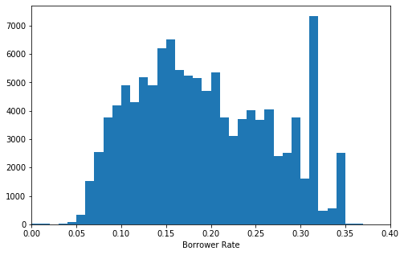

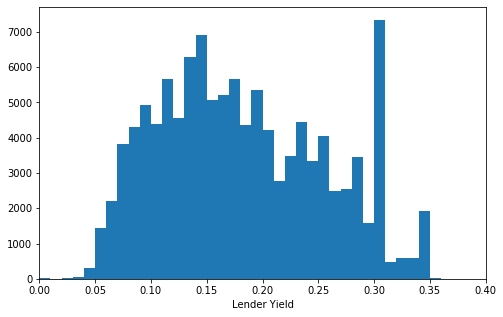

```python
#BorrowerRate
binsize = 0.01
bins1 = np.arange(0,0.4,0.01)
plt.figure(figsize = (8,5))
plt.hist(data = df, x = "BorrowerRate",bins = bins1);
plt.xlim([0,0.4])
plt.xlabel("Borrower Rate");

# LenderYield
bins2 = np.arange(-0.02,0.4,0.01)
plt.subplots(figsize = (8,5))
plt.xlim([0,0.4])
plt.hist(data = df, x = "LenderYield",bins = bins2);
plt.xlabel("Lender Yield");
```

The distribution of borrower rate is roughly an unimodal shape and it is roughly a right skew shape. The number of borrowers with the interest rate of approximately 0.32 is the largest, followed by 0.15.

The number of lenders with the lender yield of approximately 0.31 is the largest, followed by between 0.14 to 1.15.

The lender yield and Borrower Rate have similar shape of histogram, and LenderYield is a bit more volatile than the Borrower Rate.

```python
df.CreditGrade.value_counts()
```

```
C     5649
D     5153
B     4389
AA    3509
HR    3508
A     3315
E     3289
NC     141
Name: CreditGrade, dtype: int64
```

```python
df.ProsperScore.value_counts()
```

```
4.0     12595
6.0     12278
8.0     12053
7.0     10597
5.0      9813
3.0      7642
9.0      6911
2.0      5766
10.0     4750
11.0     1456
1.0       992
Name: ProsperScore, dtype: int64
```

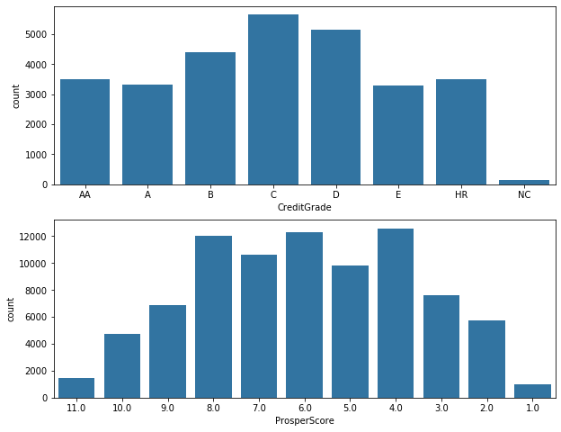

```python
# CreditGrade and ProsperScore
fig, ax = plt.subplots(nrows=2, figsize = [10,8])

default_color = sb.color_palette()[0]
sb.countplot(data = df, x = "CreditGrade", color = default_color, ax = ax[0])
sb.countplot(data = df, x = "ProsperScore", color = default_color, ax = ax[1])
```

The most of borrower's credit grades are C, and then D and B. There is very small portion in NC.

The most of borrower's sprosper score in the middle, between 8 and 4.

```python
df.Term.value_counts()
```

```
36    87778
60    24545
12     1614
Name: Term, dtype: int64
```

```python
df.IsBorrowerHomeowner.value_counts()
```

```
True     57478
False    56459
Name: IsBorrowerHomeowner, dtype: int64
```

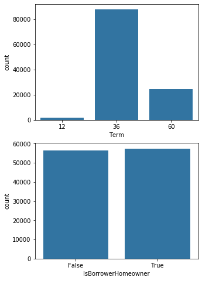

```python
# Term and IsBorrowerHomeowner
fig, ax = plt.subplots(nrows=2, figsize = [5,8])

default_color = sb.color_palette()[0]
sb.countplot(data = df, x = "Term", color = default_color, ax = ax[0] )
sb.countplot(data = df, x = "IsBorrowerHomeowner", color = default_color, ax = ax[1])
```

The most of borrowers are long-term debt,36 months (3 years) and some of them are even longer, 60 months (5 years). A vary small group of borrowers are 12 months (1 years) short-term debt.

The number of borrower who is homeowners almost the same with none-homeowners.

```python
df.EmploymentStatus.value_counts()
```

```
Employed         67322
Full-time        26355
Self-employed     6134
Not available     5347
Other             3806
Part-time         1088
Not employed       835
Retired            795
Name: EmploymentStatus, dtype: int64
```

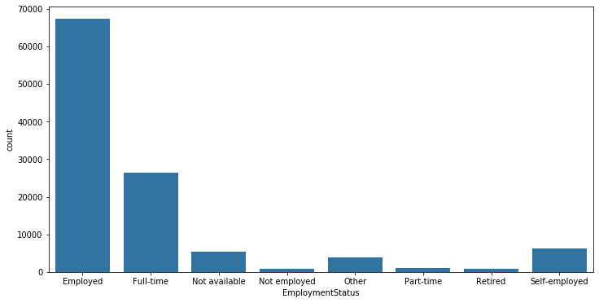

```python
# EmploymentStatus
plt.figure(figsize=(12,6))
sb.countplot(data = df, x = "EmploymentStatus", color = default_color)
```

The most of borrowers are employed, less half of them are full time. The small amout of borrowers' employment statu are partime, not employed, and retired.

```python
df.CreditScoreRangeLower.describe()
```

```
count    113346.000000
mean        685.567731
std          66.458275
min           0.000000
25%         660.000000
50%         680.000000
75%         720.000000
max         880.000000
Name: CreditScoreRangeLower, dtype: float64
```

```python
df.CreditScoreRangeUpper.describe()
```

```
count    113346.000000
mean        704.567731
std          66.458275
min          19.000000
25%         679.000000
50%         699.000000
75%         739.000000
max         899.000000
Name: CreditScoreRangeUpper, dtype: float64
```

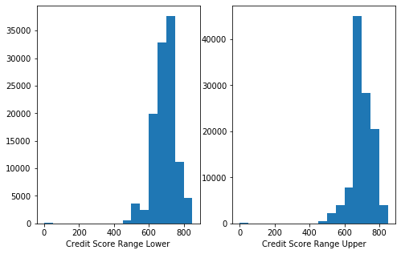

```python
# CreditScoreRangeLower
binsize = 1
plt.subplots(figsize = (8,5))
plt.subplot(1,2,1)
bins3 = np.arange(0,900,50)
plt.hist(data = df, x = "CreditScoreRangeLower", bins = bins3);
plt.xlabel("Credit Score Range Lower")

# CreditScoreRangeUpper
plt.subplot(1,2,2)
bins4 = np.arange(0,900,50)
plt.hist(data = df, x = "CreditScoreRangeUpper", bins = bins4);
plt.xlabel("Credit Score Range Upper")
```

The most of borrowers' credit score ranger lower and upper are similar, between 600 and 800.

```python
df.DebtToIncomeRatio.describe()
```

```
count    105383.000000
mean          0.275947
std           0.551759
min           0.000000
25%           0.140000
50%           0.220000
75%           0.320000
max          10.010000
Name: DebtToIncomeRatio, dtype: float64
```

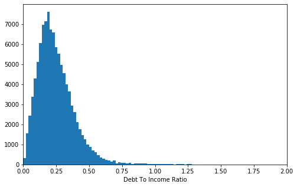

```python
# DebtToIncomeRatio
plt.subplots(figsize = (8,5))
bins5 = np.arange(0,10,0.02)
plt.hist(data = df, x = "DebtToIncomeRatio", bins = bins5 );
plt.xlim((0,2));
plt.xlabel("Debt To Income Ratio");
```

The debt to income ratio are around 0.25 for most of borrowers. Table is skewed right, while the ration skewed.

```python
# LoanOriginationDate
df["year"] = df.LoanOriginationDate.dt.year
```

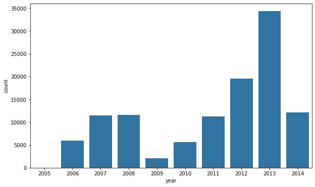

```python
plt.figure(figsize=(10,6))
sb.countplot(data = df, x = "year", color = default_color)
```

The most of borrower occured in 2013.

### **Discuss the distribution(s) of your variable(s) of interest. Were there any unusual points? Did you need to perform any transformations?**

The distribution of borrower rate is roughly an unimodal shape and it is roughly a right skew shape. The number of borrowers with the interest rate of approximately 0.32 is the largest, followed by 0.15. I don't think I need to do transformation for this variable.

### **Of the features you investigated, were there any unusual distributions? Did you perform any operations on the data to tidy, adjust, or change the form of the data? If so, why did you do this?**

When investigating the varible DebtToIncomeRatio,CreditScoreRangeLower and CreditScoreRangeUpper, I found out that there some values seem very small. Beside this, there are some outliers, but the records looks normal, so I decided not to remove them.

## Bivariate Exploration

I want to know more about the pairwise correlations present between those varibles.

### The ralationship of all variables.

```python
numeric_vars = ["BorrowerRate", "LenderYield", "CreditScoreRangeLower", "CreditScoreRangeUpper", "DebtToIncomeRatio"]
categorical_vars = ["CreditGrade", "Term", "ProsperScore", "EmploymentStatus", "IsBorrowerHomeowner","year"]
```

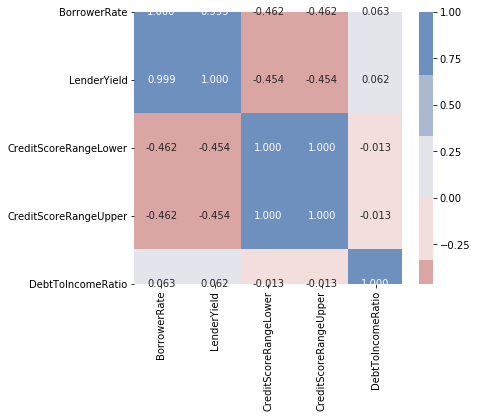

```python
# correlation plot
plt.figure(figsize = [6,5]);
sb.heatmap(df[numeric_vars].corr(), annot=True, fmt='0.3f',
           cmap = sb.color_palette('vlag_r'), center=0);
plt.show()
```

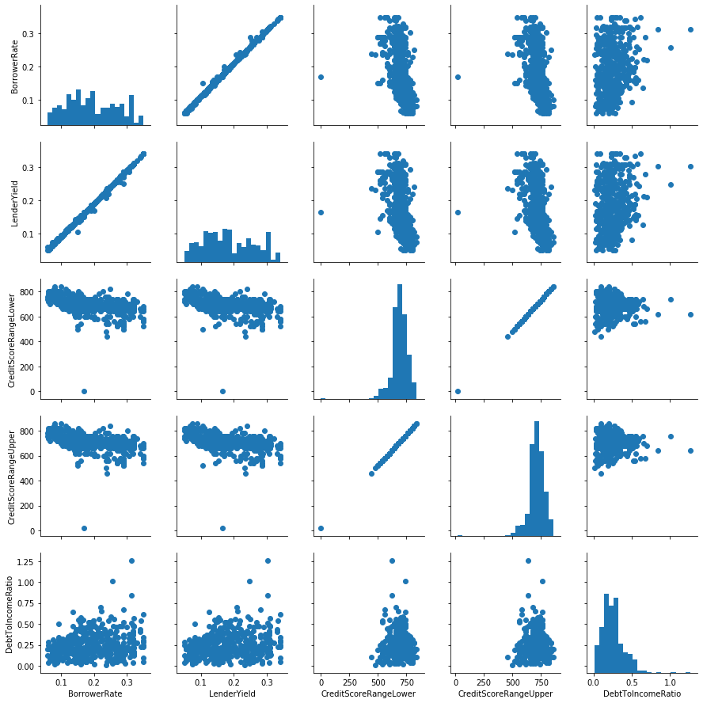

```python
# plot matrix: sample 500 borrowers' records to make the plots clearer and they render faster.
sample = np.random.choice(df.shape[0], 500, replace=False)
df_sample = df.loc[sample,:]

g = sb.PairGrid(data = df_sample, vars = numeric_vars)
g = g.map_diag(plt.hist, bins = 20);
g.map_offdiag(plt.scatter);
```

There is a strong linear relationship between the borrower’s interest rate and the lender yield.

Unexpectly, there's a weak relationship between debt to income ratio to other numeric variables.I thought the debt to income ratio is higher, the ability of paying back wo be lower, the borrower rate would be higher, and the credit score would be lower. I'm not suer yet, I'll dig into it deeper.

There might be a negative linear relationship between the borrower rate and credit score range upper and creditscorerangelower, I'll check it out later.

```python
# Creat a new column for the average of credit score.
df["CreditScoreAvg"] = (df.CreditScoreRangeUpper + df.CreditScoreRangeUpper)/2
```

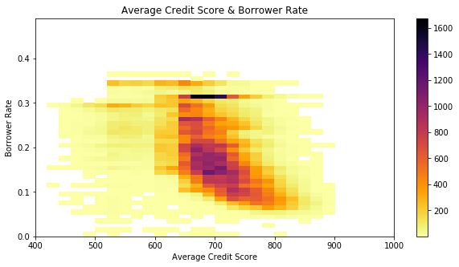

```python
# Creat a heat map to check if borrower rate and credit score average is a negative linear relationship
df_heatmap = df.loc[df.CreditScoreAvg.notnull()]

bins6 = [np.arange(400,1000,20), np.arange(0,0.5,0.01)]
plt.figure(figsize = (10,5))

plt.hist2d(data = df_heatmap, x = "CreditScoreAvg", y = "BorrowerRate", cmap = "inferno_r", cmin = 0.5, bins = bins6);
plt.xlim((400,1000));
plt.colorbar();
plt.xlabel("Average Credit Score");
plt.ylabel("Borrower Rate");
plt.title("Average Credit Score & Borrower Rate")
```

In the range of 400 to 1000 credit scores, there is indeed a negative linear relationship between the average credit score and the borrower’s interest rate. However, the higher the average credit score, the lower the borrower's interest rate tends to fall.

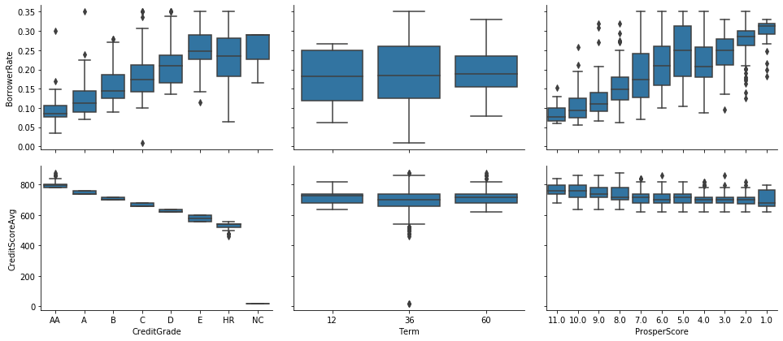

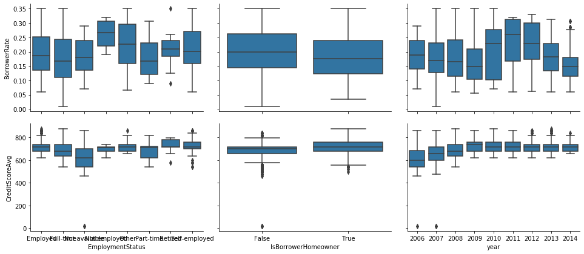

```python
# Plot matrix of numeric variables against categorical variables.
sample = np.random.choice(df.shape[0], 2000, replace=False)
df_sample = df.loc[sample,:]
categorical_vars1 = ["CreditGrade", "Term", "ProsperScore"]
categorical_vars2 = ["EmploymentStatus", "IsBorrowerHomeowner","year"]

def box_plot(x, y, **kwargs):
    sb.boxplot(x, y, color = default_color);
g2 = sb.PairGrid(data = df_sample, y_vars = ["BorrowerRate","CreditScoreAvg"], x_vars = categorical_vars1, size = 3, aspect = 1.5)
g2.map(box_plot);
g3 = sb.PairGrid(data = df_sample,y_vars = ["BorrowerRate","CreditScoreAvg"], x_vars = categorical_vars2, size = 3, aspect = 1.5)
g3.map(box_plot);
```

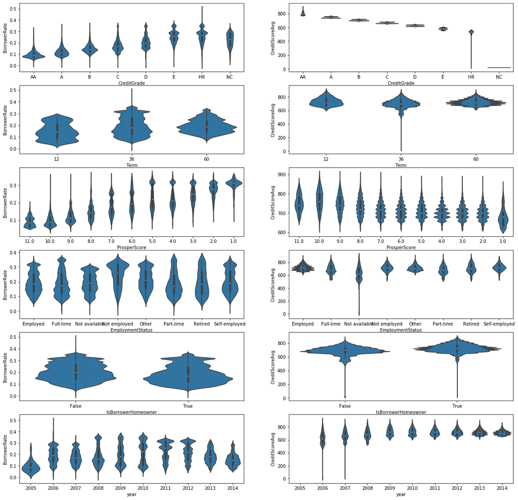

```python
# Plot the categorical variables against the BorrowerRate and CreditScoreAvg again.
fig, ax = plt.subplots(ncols = 2, nrows = 6, figsize = [20,20])
for i in range(len(categorical_vars)):
    var = categorical_vars[i]
    sb.violinplot(data = df, x = var, y = "BorrowerRate", ax = ax[i,0], color = default_color)
    sb.violinplot(data = df, x = var, y = "CreditScoreAvg", ax=ax[i,1], color = default_color)
plt.show()
```

### The relationships between categorical avriables

```python
# Term and Credit Grade.
df.loc[df.CreditGrade.notnull()].Term.unique()
```

```
[36]
Categories (1, int64): [36]
```

```python
# ProsperScore and Credit Grade.
df.loc[df.CreditGrade.notnull()].ProsperScore.unique()
```

```
[NaN]
Categories (0, object): []
```

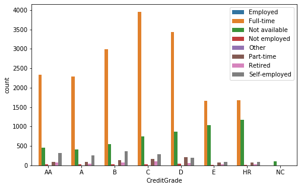

```python
# EmploymentStatus and Credit Grade.
plt.figure(figsize = (8,5));
sb.countplot(data = df, hue = "EmploymentStatus", x = "CreditGrade")
plt.legend(loc = 1)
```

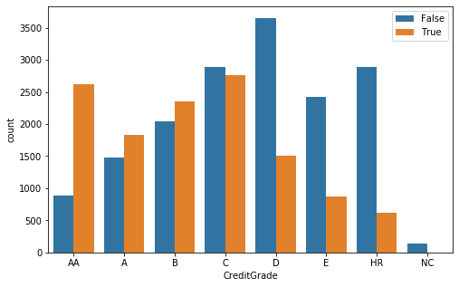

```python
# IsBorrowerHomeowner and Credit Grade
plt.figure(figsize = (8,5));
sb.countplot(data = df, hue = "IsBorrowerHomeowner", x = "CreditGrade")
plt.legend(loc = 1)
```

There are more homeowners with higher credit grade, and more none-homeowners with lower credit grade. This may be one of the reasons why homeowners have a higher credit grade than none-homeowners at a medium level and the interest rate is mainly driven by credit grade.

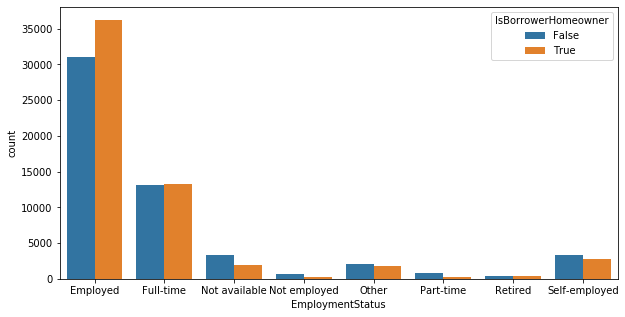

```python
# EmploymentStatus and IsBorrowerHomeowner
plt.figure(figsize = (10,5))
sb.countplot(data = df, x = "EmploymentStatus", hue = "IsBorrowerHomeowner")
```

The employment status have the same trends with if the borrower is a homeowner, which means homeowners most likely are employed or full-time employed, and none-homeowner most likely are Less part-time employed, retired, self-employed or not employed.

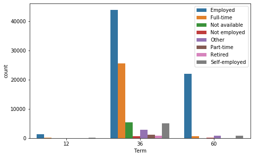

```python
# EmploymentStatus and Term
plt.figure(figsize = (8,5));
sb.countplot(data = df, hue = "EmploymentStatus", x = "Term")
plt.legend(loc = 1)
```

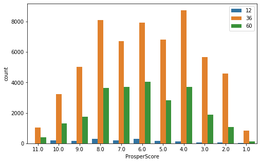

```python
#ProsperScore and Term
plt.figure(figsize = (8,5));
sb.countplot(data = df, hue = "Term", x = "ProsperScore")
plt.legend(loc=1)
```

As the prosper score decreases, all terms seem to have a similar trend.

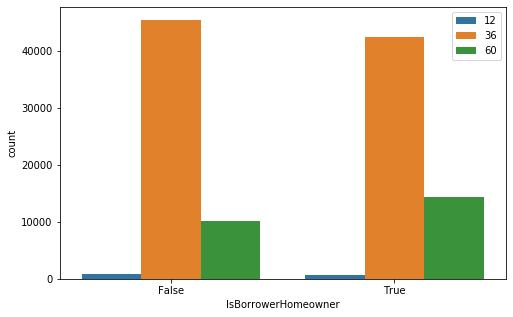

```python
# IsBorrowerHomeowner and Trem
plt.figure(figsize = [8,5]);
sb.countplot(data = df, hue = "Term", x = "IsBorrowerHomeowner")
plt.legend(loc = 1)
```

The IsBorrowerHomeowner doesn't have ralationship with terms, because the portions of each term are similar.

### Talk about some of the relationships you observed in this part of the investigation. How did the feature(s) of interest vary with other features in the dataset?

The borrower’s interest rate seems to be highly correlated with the credit score. After plotting the heat map, I noticed a negative linear relationship between the average credit score and the borrower’s interest rate. There is no obvious relationship between the borrower’s interest rate and other numerical variables. To my surprise, DebtToIncomeRatio does not seem to be related to the borrowing rate.

### Did you observe any interesting relationships between the other features (not the main feature(s) of interest)?

I found out that borrowers who are employed are often homeowners.

## Multivariate Exploration

The main thing I want to explore in this part is how the relationship of the borrower rate and the average credit score affected by the variables that seems have no effect from the previous analysis, including "DebtToIncomeRatio", "EmploymentStatus", "IsBorrowerHomeowner", "year".

```python
df.CreditScoreAvg.describe()
```

```
count    113346.000000
mean        704.567731
std          66.458275
min          19.000000
25%         679.000000
50%         699.000000
75%         739.000000
max         899.000000
Name: CreditScoreAvg, dtype: float64
```

```python
def hist2dplot(x, y, **kwargs):
    bins_x = np.arange(15,900,20)
    bins_y = np.arange(0,0.5,0.02)
    plt.hist2d(x, y, bins = [bins_x, bins_y], cmap = "inferno_r", cmin = 0.5)
```

```
(400, 1000)
```

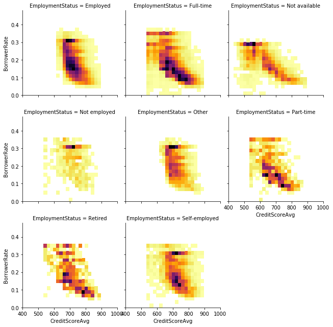

```python
# BorrowerRate & CreditScoreAvg & EmploymentStatus
p = sb.FacetGrid(data = df, col = "EmploymentStatus", col_wrap = 3)
p.map(hist2dplot,"CreditScoreAvg","BorrowerRate")
plt.xlim((400,1000))
```

The employed or full-time employed borrowers have more records on the lower right and high credit score with lower borrower’s interest rate, especailly for full-time employed borrowers.

```
(400, 1000)
```

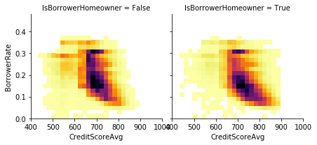

```python
# BorrowerRate & CreditScoreAvg & IsBorrowerHomeowner
p = sb.FacetGrid(data = df, col = "IsBorrowerHomeowner", col_wrap = 3)
p.map(hist2dplot,"CreditScoreAvg","BorrowerRate")
plt.xlim((400,1000))
```

The none-homeowner have more records in upper left and lower credit score with higher borrower’s interest rate.

```
(400, 1000)
```

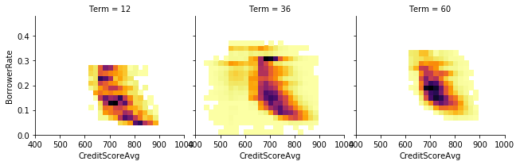

```python
p = sb.FacetGrid(data = df, col = "Term", col_wrap = 3)
p.map(hist2dplot,"CreditScoreAvg","BorrowerRate")
plt.xlim((400,1000))
```

```
(400, 1000)
```

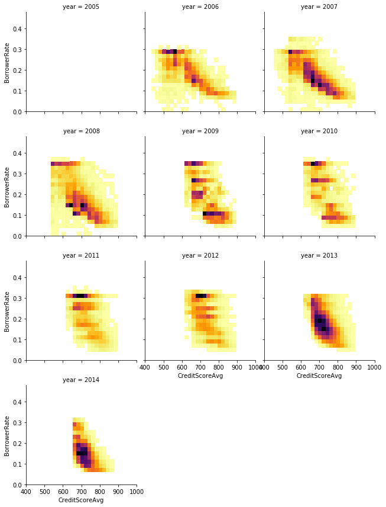

```python
# BorrowerRate & CreditScoreAvg & "year"
p = sb.FacetGrid(data = df, col = "year", col_wrap = 3)
p.map(hist2dplot,"CreditScoreAvg","BorrowerRate")
plt.xlim((400,1000))
```

Over the past year, the slope of the average credit score and the borrower’s interest rate are getting steeper, which means that the borrower ’s interest rate is becoming more and more sensitive to changes in credit score.

```
(0, 1)
```

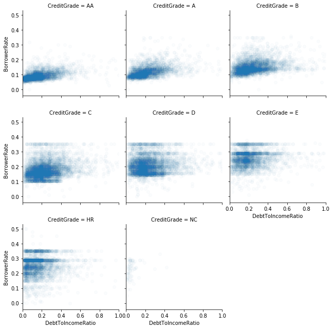

```python
# CreditGrade & DebtToIncomeRatio & BorrowerRate
p = sb.FacetGrid(data = df, col = "CreditGrade", col_wrap = 3)
p.map(plt.scatter,"DebtToIncomeRatio", "BorrowerRate", alpha = 0.02)
plt.xlim((0,1))
```

After limiting the range of DebtToIncomeRatio to eliminate outliers, we can see that there is a roughly positive linear relationship between the borrower's interest rate and debt-to-income ratio for each credit grade, especially for AA, A, and B.

### Talk about some of the relationships you observed in this part of the investigation. Were there features that strengthened each other in terms of looking at your feature(s) of interest?

In the bivariate exploration section, I did not see a clear relationship between the variables DebtToIncomeRatio and BorrowerRate. However, in the multivariate exploration section, I noticed that after limiting the range of DebtToIncomeRatio to eliminate outliers, there is a roughly positive linear relationship between the borrower’s interest rate and debt to income ratio for each credit level, which is more obvious in credit grade AA, A and B.

### Were there any interesting or surprising interactions between features?

Secondly, I found out that the slope of the average credit score and the borrower rate became steeper as the year increased, which meant that the borrower’s interest rate was increasingly sensitive to changes in credit score.